# Ali Shahidi Student Number= 810194341

At this part, I include some libraries which I will use them in other parts:  
1) numpy will be used as a replacement for Python list ( because it is faster compared with Python's list since it utilizes contiguous memory for  
storing variables, and there is no need for type checking when iterating through objects )  
2) Pandas will be used for working with large amounts of data since it has so many methods that we can apply them when working with these  
amounts of data.  
3) Matplotlib will be used for drawing scatter plots.

در این بخش کتابخانه های مورد نیاز را در برنامه قرار دادم.

```python
import numpy as np
import pandas as pd
import matplotlib.pyplot as plt
```

ابتدا داده ها را از فایل خوانده و سپس بعضی از ستون ها و سطرهای آن را چاپ کردم

```python
file_name = "houses.csv"
df = pd.read_csv(file_name)
sale_price = "SalePrice"
print(df.iloc[0:5,0:7])
print("\n\n", df.describe)
```

```
   Id  MSSubClass  LotArea LotConfig  OverallQual  LotFrontage Neighborhood
0   1          60     8450    Inside            7         65.0      CollgCr
1   2          20     9600       FR2            6         80.0      Veenker
2   3          60    11250    Inside            7         68.0      CollgCr
3   4          70     9550    Corner            7         60.0      Crawfor
4   5          60    14260       FR2            8         84.0      NoRidge


 <bound method NDFrame.describe of         Id  MSSubClass  LotArea LotConfig  OverallQual  LotFrontage  \
0        1          60     8450    Inside            7         65.0
1        2          20     9600       FR2            6         80.0
2        3          60    11250    Inside            7         68.0
3        4          70     9550    Corner            7         60.0
4        5          60    14260       FR2            8         84.0
...    ...         ...      ...       ...          ...          ...
```

[output cut: 33 more lines]

In this section, I deleted those columns which were not required for other parts by "drop" function.

در این بخش ستون هایی که مربوط به داده های طبقه ای بودند و نیازی به آن ها نبود را حذف کردم.

```python
for i in range(len(df.columns)):
    if i < len(df.columns) and (df.dtypes[i] == "object" or df[df.columns[i]].name == "Id"):
            df.drop([df.columns[i]],  axis='columns', inplace = True)
print("Data set after deleting unnecessary columns = \n", df)
```

```
Data set after deleting unnecessary columns =
       MSSubClass  LotArea  OverallQual  LotFrontage  OverallCond  \
0             60     8450            7         65.0            5
1             20     9600            6         80.0            8
2             60    11250            7         68.0            5
3             70     9550            7         60.0            5
4             60    14260            8         84.0            5
...          ...      ...          ...          ...          ...
1129          20    13072            6         63.0            5
1130          20     9037            8         64.0            5
1131          60     8158            7         65.0            5
1132          20     9849            7         83.0            6
1133          85    10625            7         85.0            6

      BedroomAbvGr  TotRmsAbvGrd  TotalBsmtSF  YearBuilt  SalePrice
0                3             8          856       2003    208.500
1                3             6         1262       1976    181.500
2                3             6          920       2001    223.500
3                3             7          756       1915    140.000
4                4             9         1145       2000    250.000
...            ...           ...          ...        ...        ...
1129             3             6         1141       2005    142.500
1130             2             6         1476       2006    265.900
1131             3             8          884       2003    224.900
1132             3             7         1689       2007    248.328
1133             3             6         1053       1974    170.000

[1134 rows x 10 columns]
```

According to the project statement, some of the variables have not been initialized, so I was made to initialize them with the average value of every column that they were in. I used "fillna" function for this purpose.

همانطور که در صورت پروژه اشاره شده بود بعضی از داده ها مقدار اولیه نداشتند بنابراین باید میانگین هر ستون که داده در آن بود را به عنوان مقدار آن داده قرار میدادیم. این بخش این کار را انجام میدهد

```python
print("NaN value? \n",df.isnull().any())
print("\nColumn average = \n", df.mean())
df.fillna(df.mean(), inplace = True)
print("\nNaN value? \n",df.isnull().any())
print(df.head(10))
```

```
NaN value?
 MSSubClass      False
LotArea         False
OverallQual     False
LotFrontage      True
OverallCond     False
BedroomAbvGr    False
TotRmsAbvGrd    False
TotalBsmtSF     False
YearBuilt       False
SalePrice       False
dtype: bool

Column average =
 MSSubClass        54.056437
LotArea         9487.280423
OverallQual        6.065256
LotFrontage       68.405550
OverallCond        5.551146
BedroomAbvGr       2.828924
TotRmsAbvGrd       6.354497
TotalBsmtSF     1032.037037
YearBuilt       1972.981481
SalePrice        174.783949
dtype: float64

NaN value?
 MSSubClass      False
LotArea         False
OverallQual     False
LotFrontage     False
OverallCond     False
BedroomAbvGr    False
TotRmsAbvGrd    False
TotalBsmtSF     False
YearBuilt       False
SalePrice       False
dtype: bool
   MSSubClass  LotArea  OverallQual  LotFrontage  OverallCond  BedroomAbvGr  \
0          60     8450            7     65.00000            5             3
1          20     9600            6     80.00000            8             3
2          60    11250            7     68.00000            5             3
3          70     9550            7     60.00000            5             3
4          60    14260            8     84.00000            5             4
5          50    14115            5     85.00000            5             1
6          20    10084            8     75.00000            5             3
7          60    10382            7     68.40555            6             3
8          50     6120            7     51.00000            5             2
9          20    11200            5     70.00000            5             3

   TotRmsAbvGrd  TotalBsmtSF  YearBuilt  SalePrice
0             8          856       2003      208.5
1             6         1262       1976      181.5
2             6          920       2001      223.5
3             7          756       1915      140.0
4             9         1145       2000      250.0
5             5          796       1993      143.0
6             7         1686       2004      307.0
7             7         1107       1973      200.0
8             8          952       1931      129.9
9             5         1040       1965      129.5
```

In this part, I just drew scatter plots to show the relationships among each column with the "SalePrice". All plots have a label in order to clarify which one of the columns is used as an x-axis.

در اینجا نمودار هر ستون بر حسب قیمت خانه رسم شده است.

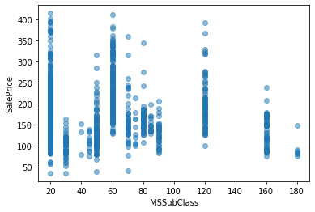

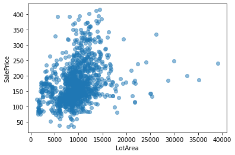

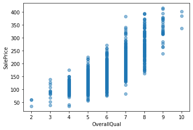

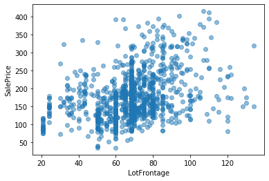

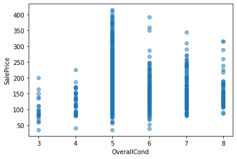

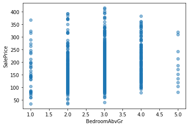

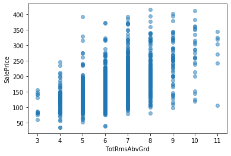

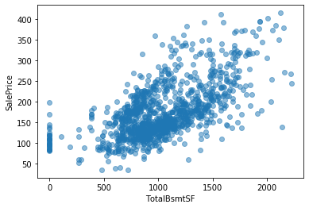

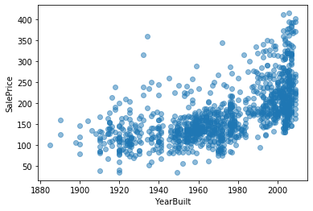

```python
for i in range(len(df.columns)):
    if df[df.columns[i]].name == "Id" or df[df.columns[i]].name == sale_price:
        continue
    plt.scatter(df[df.columns[i]].values, df[sale_price].values, alpha=0.5)
    plt.xlabel(df[df.columns[i]].name)
    plt.ylabel(sale_price)
    plt.show()
```

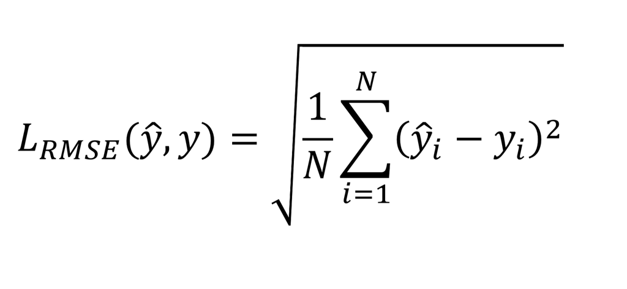

w = 90

b = 14

column = "OverallQual"

RMSE = 51.881394662627606

The red spots in the plot are the linear function which is used for price prediction.

نقطه های قرمز بر روی نمودار نشان دهنده نمودار خطی است که برای پیش بینی قیمت استفاده شده است.

```
RMSE =  51.881394662627606
```

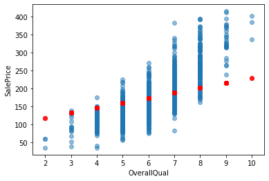

```python
w = 90
b = 14
zigma_err = 0
columns_ind_b = "OverallQual"
data_size = len(df[columns_ind_b])
price_predicted = np.zeros(len(df[columns_ind_b]))
for i in range(len(df[columns_ind_b])):
    price_predicted[i] = (b * df[columns_ind_b].values[i]) + w
    zigma_err = zigma_err + ((price_predicted[i] - df[sale_price].values[i]) ** 2)
rmse = np.sqrt(zigma_err / data_size)
print("RMSE = ", rmse)

plt.scatter(df[columns_ind_b].values, df[sale_price].values, alpha=0.5)
plt.scatter(df[columns_ind_b].values, price_predicted, alpha=0.5, color="red")
plt.xlabel(columns_ind_b)
plt.ylabel(sale_price)
plt.show()
```

Part C, this part is exactly like part B, but the major difference is I did not use any loop for this code, and I implemented it just by utilizing the broadcast ability of Numpy library.

```
RMSE =  51.881394662627656
```

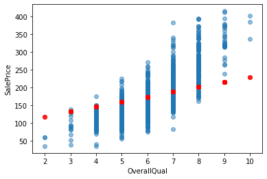

```python
price_predicted = np.zeros(len(df[columns_ind_b]))
price_predicted = (b * df[columns_ind_b].values) + w
zigma_err = np.sum((price_predicted - df[sale_price].values) ** 2)
rmse = np.sqrt(zigma_err / data_size)
print("RMSE = ", rmse)

plt.scatter(df[columns_ind_b].values, df[sale_price].values, alpha=0.5)
plt.scatter(df[columns_ind_b].values, price_predicted, alpha=0.5, color="red")
plt.xlabel(columns_ind_b)
plt.ylabel(sale_price)
plt.show()
```

"data_normalization" is implemented in order to normalize the data of each column which will be used for K Nearest Neighbors problem. first, I wrote a code for finding the maximum and minimum of each column, and then I used the formula which I found in http://saedsayad.com/k_nearest_neighbors_reg.htm . for each cell in the data set, I calculated a normalization value. The formula is x = (x - min) / (max - min).

در لینکی که در صورت پروژه آمده است فرمول نرمالیزه کردن با استفاده از ماکزیمم و مینیمم هر ستون آمده است. در این تابع آن فرمول را پیاده سازی کرده ام.

```python
def data_normalization(singular_df, df):
    for i in range(len(df.columns)):
        if df[df.columns[i]].name == sale_price:
            continue
        max_row = np.amax(pd.concat([df, singular_df], ignore_index = True, sort=False)[df.columns[i]].values)
        min_row = np.amin(pd.concat([df, singular_df], ignore_index = True, sort=False)[df.columns[i]].values)
        df[df.columns[i]] = (df[df.columns[i]].values - min_row) / (max_row - min_row)
        singular_df[singular_df.columns[i]] = (singular_df[singular_df.columns[i]].values - min_row) / (max_row - min_row)
```

implementation of "data_normalization" without a loop.

الگوریتم بالا بدون حلقه

```python
def data_normalization_knn(singular_df, df):
    max_row = np.zeros(len(df.columns))
    min_row = np.zeros(len(df.columns))
    max_row = np.amax(pd.concat([df, singular_df], ignore_index = True, sort=False).loc[:, df.columns != sale_price]).max(level=0)
    min_row = np.amin(pd.concat([df, singular_df], ignore_index = True, sort=False).loc[:, df.columns != sale_price]).min(level=0)
    df.loc[:, df.columns != sale_price] = (df.loc[:, df.columns != sale_price].values - min_row.values) / (max_row.values - min_row.values)
    singular_df.loc[:, singular_df.columns != sale_price] = (singular_df.loc[:, singular_df.columns != sale_price].values - min_row.values) / (max_row.values - min_row.values)
```

The main part of this Project! in this function, first, I inserted "SalePrice" column to input data set, "singular_df", and after normalization, the input (has only one row) is subtracted from every row in the "df"( is read from file), then, each cell, except the cells in "SalePrice", multiplies by itself, and results are replaced with the older values in "df", after that, every cell is added with every other cell in one row, except the cells in "SalePrice", and the square root of these sums store in new column which is named "euclidian". By using sort function, I sorted all results based on the value of "euclidian" column, and I calculated the average house's price of the first 10 rows and put the result as the price of input house.

در این تابع ابتدا ستون قیمت را به مجموعه داده ورودی اضافه کردم و سپس داده های ورودی و مجموعه داده ها را نرمالیزه کردم. سپس مجموعه داده ورودی نرمالیزه شده را از هر سطر داده اصلی نرمالیزه شده کم کردم و پس از ضرب کردن هر سلول داده اصلی در خودش. سلولهای جدید را جایگزین سلولهای قبلی کردم. سپس همه داده های موجود در هر سطر را با هم جمع کرده و جذرشان را گرفتم و در ستون جدیدی در داده های اصلی به نام ستون اقلیدسی قرار دادم. پس از مرتب کردن مجموعه داده ها بر حسب ستون اقلیدسی میانگین 10 قیمت خانه ای که اطلاعاتش مانند خانه ورودی است را حساب کردم و به عنوان قیمت خانه جدید در ستون مربوطش قرار دادم.

```python
def knn(singular_df):
    df_knn = df.copy()
    singular_df_knn = singular_df.copy()
    singular_df_knn.insert(len(df_knn.columns) - 1 ,sale_price,0)
    singular_df_knn.fillna(singular_df_knn.mean(), inplace = True)

    data_normalization_knn(singular_df_knn,df_knn)

    df_knn =  abs(singular_df_knn.values[0] - df_knn )
    df_knn.loc[:, df_knn.columns != sale_price] = df_knn.loc[:, df_knn.columns != sale_price] ** 2
    df_knn.insert(len(df_knn.columns) ,"euclidan",0)
    df_knn["euclidan"] = df_knn.loc[:, df_knn.columns != sale_price].sum(axis = 1, skipna = True)
    df_knn["euclidan"] = np.sqrt(df_knn["euclidan"])

    df_knn.sort_values('euclidan', ascending=True, inplace=True)
    df_knn.reset_index(drop=True, inplace=True)
    singular_df_knn[sale_price].values[0] = float(df_knn.loc[0:9,[sale_price]].sum()/10)

    return  singular_df_knn["SalePrice"].values[0]
```

singular_df = example of input data set

```python
columns = ['MSSubClass', 'LotArea', 'OverallQual', 'LotFrontage', 'OverallCond',
           'BedroomAbvGr', 'TotRmsAbvGrd', 'TotalBsmtSF', 'YearBuilt']
row_data = [70,11435,8,67.66037735849056,7,3,7,792,1929]

singular_df = pd.DataFrame(data = [row_data], columns = columns)
sale_price_pre = knn(singular_df)
print("predicted price = ", sale_price_pre)
```

```
predicted price =  173
```

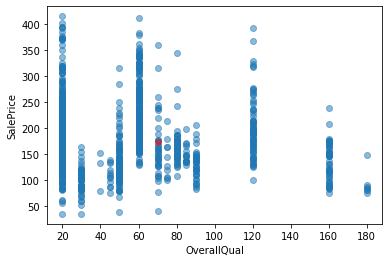

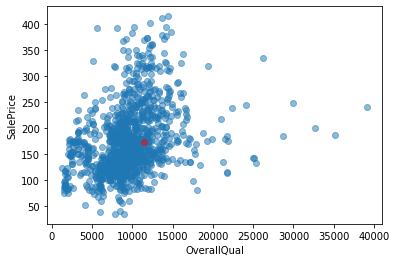

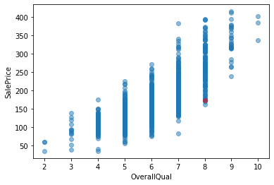

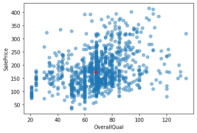

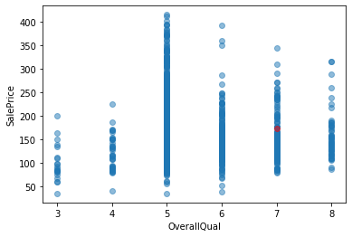

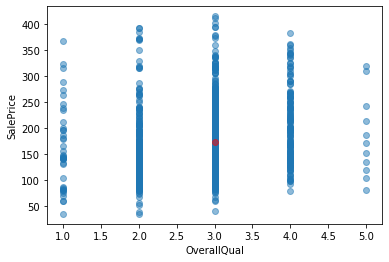

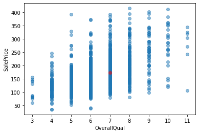

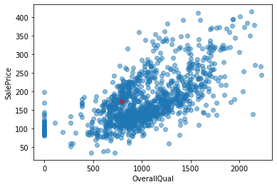

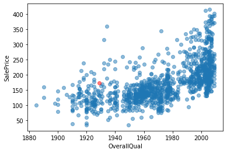

```python
for i in range(len(df.columns)):
    if df[df.columns[i]].name == "Id" or df[df.columns[i]].name == sale_price:
        continue
    plt.scatter(df[df.columns[i]].values, df[sale_price].values, alpha=0.5)
    plt.scatter(singular_df[singular_df.columns[i]].values, sale_price_pre, alpha=0.5, color="red")
    plt.xlabel(columns_ind_b)
    plt.ylabel(sale_price)
    plt.show()
```